# Multiple Imputation of Missing Values in Stock Prices Data

## 1. Motivation

Financial stock market data, for various reasons, frequently contain missing values. One reason for this is that, a value for stock is observed only when a trade order is executed from the limit order books and stock value for each minute is not always observed. Investment banks are interested in this minute by minute stock price information as they use these prices to price other derivatives or hedge their risks from other riskier trades. Typically, one can use the last seen values of these stock prices or one could use other methods of imputation used in literature. One drawback of using the *last value carried forward* method is it assumes that prices remain unchanged when there is no data. The drawback of using simulations based imputation based methods is twofold - firstly, the time it takes to run multiple simulations can be more than the frequency of the data; secondly, more than 80 percent of the data has missing values. Further, it would be naive to assume that the missing values are *MCAR(missing completely at random)*. Under these circumstances, we assume that the missing data depends on the observed entries and we can use information of other similar stocks to form better estimates for the missing values.  
For instance, it can be seen from data that the stock prices for the five biggest tech firms, namely Apple, Facebook, Microsoft, Google and Amazon would move together in the same direction. The main goal of this study is to combine stock price data of these related stocks and develop an algorithm to impute the missing values in individual stock prices using “information-sharing” between different time series. To develop this imputation algorithm for the stock price time series data, we model the stock prices as a dynamic linear model. We compute the posterior distribution of the parameters of the model given the past data and simulate them using *Gibbs Sampler* to find the best estimate of the missing values.

## 2. Data Description

In this section, we will describe the data and validate our assumptions. We have tick data of the five tech stocks - Google, Facebook, Amazon, Apple, Microsoft from 2,Jan,2020 to 14, Jan, 2020. All the stock prices are captured at different frequencies. At any given time we may or may not observe the stock prices. The following table represents the data observed for *Apple* stock.

```python
import pandas as pd
import pickle
import matplotlib.pyplot as plt
from pandas.plotting import scatter_matrix
from pandas.plotting import autocorrelation_plot
import numpy as np
file_list = ['apple', 'google', 'microsoft', 'facebook', 'amazon']
apple_data = pd.read_csv('apple.csv')
print(apple_data.head(n=5))
```

```
       Date     Time    Open    High     Low   Close  Volume
0  1/2/2020  4:00:00  295.05  295.08  295.05  295.08    8910
1  1/2/2020  4:06:00  295.35  295.59  295.35  295.59     719
2  1/2/2020  4:08:00  295.55  295.55  295.55  295.55     266
3  1/2/2020  4:09:00  295.74  295.75  295.74  295.75    1410
4  1/2/2020  4:10:00  295.60  295.60  295.60  295.60    1000
```

Similarly, we can see the data captured for *Google* below

```python
google_data = pd.read_csv('google.csv')
print(google_data.head(n=5))
```

```
       Date     Time     Open     High      Low    Close  Volume
0  1/2/2020  4:00:00  1342.00  1342.20  1342.00  1342.20     424
1  1/2/2020  4:02:00  1344.20  1344.20  1344.20  1344.20     177
2  1/2/2020  8:00:00  1337.02  1337.02  1337.02  1337.02     329
3  1/2/2020  8:09:00  1347.00  1347.00  1347.00  1347.00     155
4  1/2/2020  8:55:00  1348.00  1348.00  1348.00  1348.00     190
```

Notice that the tick frequencies of the two data sets are very different. We now combine these data sets such that we have data has a freq of 1 minute, and we have the stock prices of the five firms as columns.

### 2.1 Data Cleaning

```python
series = pd.date_range(start='1/2/2020', end='1/2/2020', freq='T') # create the dummy dataframe
time_series = pd.DataFrame({'Time': series})

for file in file_list: # read all csv files one by one
    raw = pd.read_csv(file + '.csv')
    raw[file] = raw['Close']
    raw['Time'] = raw['Date'] + ' ' + raw['Time']
    raw['Time'] = pd.to_datetime(raw['Time'], format='%m/%d/%Y %H:%M:%S')
    raw = raw[['Time', file]]
    raw = raw.set_index('Time')
    time_series = pd.merge(time_series, raw, on='Time', how='outer') # combine all datasets to the dummy frame
time_series = time_series.sort_values(by='Time')
time_series = time_series.set_index('Time')
time_series = time_series.asfreq(freq='T')
print(time_series.tail(n=10)) # print the last 10 values of data
pickle.dump(time_series, open('real_data_original.p','wb')) # store the dataset as pickle file
```

```
                      apple  google  microsoft  facebook  amazon
Time
2020-01-14 03:51:00     NaN     NaN        NaN       NaN     NaN
2020-01-14 03:52:00     NaN     NaN        NaN       NaN     NaN
2020-01-14 03:53:00     NaN     NaN        NaN       NaN     NaN
2020-01-14 03:54:00     NaN     NaN        NaN       NaN     NaN
2020-01-14 03:55:00     NaN     NaN        NaN       NaN     NaN
2020-01-14 03:56:00     NaN     NaN        NaN       NaN     NaN
2020-01-14 03:57:00     NaN     NaN        NaN       NaN     NaN
2020-01-14 03:58:00     NaN     NaN        NaN       NaN     NaN
2020-01-14 03:59:00     NaN     NaN        NaN       NaN     NaN
2020-01-14 04:00:00  316.06     NaN     162.98    221.75  1885.0
```

This data set will have a lot of missing values, we also create a *last value carried forward* dataset from this one and remove all entries where we have no information on any of the five stocks.

```python
time_series_ff = time_series.fillna(method='ffill')
time_series_ff = time_series_ff.dropna(axis=0, how='all', thresh=None, subset=None, inplace=False)

print(time_series_ff.tail(n=10))
```

```
                      apple  google  microsoft  facebook   amazon
Time
2020-01-14 03:51:00  318.78  1440.0     163.70    222.20  1892.52
2020-01-14 03:52:00  318.78  1440.0     163.70    222.20  1892.52
2020-01-14 03:53:00  318.78  1440.0     163.70    222.20  1892.52
2020-01-14 03:54:00  318.78  1440.0     163.70    222.20  1892.52
2020-01-14 03:55:00  318.78  1440.0     163.70    222.20  1892.52
2020-01-14 03:56:00  318.78  1440.0     163.70    222.20  1892.52
2020-01-14 03:57:00  318.78  1440.0     163.70    222.20  1892.52
2020-01-14 03:58:00  318.78  1440.0     163.70    222.20  1892.52
2020-01-14 03:59:00  318.78  1440.0     163.70    222.20  1892.52
2020-01-14 04:00:00  316.06  1440.0     162.98    221.75  1885.00
```

### 2.2 Data Visualization

We will now plot this *last value carried forward* data set to find any useful correlations and trends in this data.

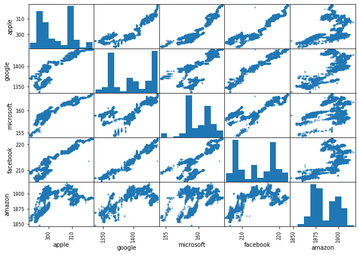

```python
scatter_matrix(time_series_ff, figsize =(10, 7))
plt.show()
```

We now look at the autocorrelation plots for these stocks below. We notice that all the stock prices are significantly positively correlated to their past values upto $t=6000$

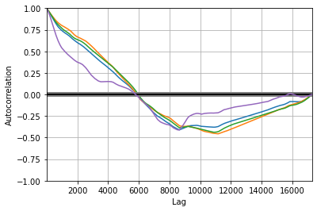

```python
ax = autocorrelation_plot(time_series_ff['apple'])
autocorrelation_plot(time_series_ff['google'], ax=ax)
autocorrelation_plot(time_series_ff['facebook'], ax=ax)
autocorrelation_plot(time_series_ff['amazon'], ax=ax)
autocorrelation_plot(time_series_ff['microsoft'], ax=ax)
```

Further, we also try to look at the covariance between all these stocks and their general trends in the figures below.

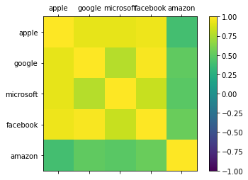

```python
correlations = time_series_ff.corr()
fig = plt.figure()
ax = fig.add_subplot(111)
cax = ax.matshow(correlations, vmin=-1, vmax=1)
fig.colorbar(cax)
ticks = np.arange(0, 5, 1)
ax.set_xticks(ticks)
ax.set_yticks(ticks)
ax.set_xticklabels(file_list)
ax.set_yticklabels(file_list)
plt.show()
```

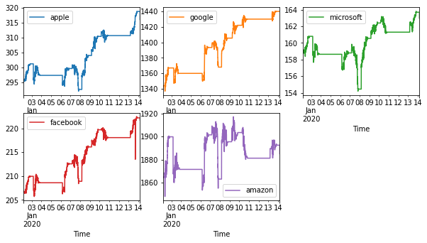

```python
time_series_ff.plot(subplots=True, layout=(2,3), sharex=False, figsize= (10,5))
plt.show()
```

## 3. Model

We will now setup the linear dynmic model for the data. We assume that the stock price data $\mathbf{Y}_t$ can be given as :

\begin{eqnarray} \mathbf{Y_t} = \theta_t + V_t \end{eqnarray}

where, $\theta_t$ is the latent state variable. We assume that $V_t$ is a normally distributed with parameters $N(0, \Sigma_t)$. This implies that the observed $\mathbf{Y}_t \sim N(\theta_t, \Sigma_t)$. Since we donot observe the latent variable $\theta_t$, we have a prior that $\theta_t|_{\mathbf{y_1,\cdots \mathbf{y}_n}, \Sigma_t} \sim N(\mu_n,\Lambda_n)$

Further, we assume that $\Sigma_t \sim Inverse Wishart (\nu, \psi)$

Notice that $\mathbf{Y}_t$ is not fully observed, i.e at any given time time $t$, $\mathbf{Y}_t$ will have a a few missing stock prices $\mathbf{Y}_{mis, t}$ and few observed prices $ \mathbf{Y}_{obs, t}$. Our goal is to jointly estimate $\Sigma_t, \theta_t, \mathbf{Y}_{mis,t}$.

Let the prior distribution of the variables be given as

\begin{eqnarray} &\theta_t \sim N(\mu_0, \Lambda_0)\\ &\Sigma_t \sim InvWishart(\mu_0, \psi_0) \end{eqnarray}

Then, we can update these distributions using data and from Hoff 2007, we have that the posterior distribution can given as :

\begin{eqnarray} &\theta_n|_{\mathbf{y_1,\cdots \mathbf{y}_n}, \Sigma_t} \sim N(\mu_n, \Lambda_n)\\ &\Sigma_n|_{\mathbf{y_1,\cdots \mathbf{y}_n}, \theta_t} \sim InvWishart(\nu_0 + n, \psi_n)\\ &\mathbf{Y}_{mis, n}|_{\theta_t, Sigma_t,\mathbf{y_1,\cdots \mathbf{y}_{obs,n}} } \sim N(\theta_p, \Sigma_p) \end{eqnarray}

where, \begin{eqnarray} & \mu_n = (\Lambda_o{}^{-1} + n \sigma_n{}^{-1})^{-1} (\Lambda_o{}^{-1} \mu_0 + n \sigma_n{}^{-1}\bar{\mathbf{y}} ) & \Lambda_n = (\Lambda_0{}^{-1} + n \sigma_n{}^{-1})^{-1}\\ & \psi_n = (\psi_0 + \sum_{i=1}^{n}(\mathbf{y}_i - \theta_n)(\mathbf{y}_i - \theta_n)^{T})^{-1} & \\ & \theta_p = \theta_{mis,n} + \Sigma_{mis,obs,n} (\Sigma_{obs,obs,n})^{-1}(\mathbf{y}_{obs,n} - \theta_{obs,n})& \Sigma_p = Sigma_{mis,mis,n} - \Sigma_{mis,obs,n} (\Sigma_{obs,obs,n})^{-1} \Sigma_{obs,mis,n} \end{eqnarray}

## 4 Methodology and Model Validation

While $\Sigma, \theta$ are unknown and need to be updated using $\mathbf{Y}$, notice that $\mathbf{Y}$ itself is not completely observed. While we know the *full conditional distribution* of each of these quantities, we need Gibbs sampler to have an estimate of the joint probability.

Furthermore, since the true values are never observed, we test our algorithm on dataset we generate. More specifically we generate a stock price data set using Geometric brownian motion, we then randomly delete some of the data entries of the data. Finally we use our bayesian update with Gibbs sampling to estimate the missing values. Finally we will compare the **Mean Squared Error** of our algorithm with the *last value carried forward*

We will now describe our algorithm, then generate the dataset and find the Mean squared error from our algorithm.

### 4.1 Algorithm

a. Sample $\theta$ from $N(\mu_n, \Lambda_n)$ where $\mu_n, \Lambda_n $ are computed using the initial values of $\sigma$ and $\mathbf{Y}$.

b. Using this sample $\theta$, compute $\psi_n$ and sample $\Sigma$ from $InvWishart(\nu_0 + n, \psi_n)$.

c. Finally, sample $\mathbf{Y}_{mis, n}$ from $N(\theta_p, \Sigma_p)$

### 4.2 Genearting Mock dataset

```python
import random

def gen_paths(S0, r, sigma, T, M, I): # function that generates a geometric brownian motion
    dt = float(T) / M
    paths = np.zeros((M + 1, I), np.float64)
    paths[0] = S0
    for t in range(1, M + 1):
        rand = np.random.standard_normal(I)
        paths[t] = paths[t - 1] * np.exp((r - 0.5 * sigma ** 2) * dt +
                                         sigma * np.sqrt(dt) * rand)

    return paths

def generate_incomplete_data(T):
    data = {'apple': gen_paths(50, .50, .15, 1, T, 100)[:, -1].tolist(),
            'facebook': gen_paths(100, .65, .25, 1, T, 100)[:, -1].tolist(),
            'google': gen_paths(75, .25, .34, 1, T, 100)[:, -1].tolist(),
            'amazon': gen_paths(30, .3, .24, 1, T, 100)[:, -1].tolist(),
            'microsoft': gen_paths(45, .35, .5, 1, T, 100)[:, -1].tolist()}
    path = pd.DataFrame(data, columns=['apple', 'facebook', 'google', 'amazon', 'microsoft'])
    pickle.dump(path, open('data_mock_complete.p','wb'))

    for rows in range(len(path)):
        num_missing = random.randrange(0, 4)
        missing_index = random.sample(list(range(0, 5)), num_missing)  # return [] when num_missing is 0
        cols = ['apple', 'facebook', 'google', 'amazon', 'microsoft']
        if missing_index is not None:
            for i in missing_index:
                path[cols[i]].iloc[rows] = 0
    pickle.dump(path, open('data_mock_incomplete.p','wb'))
    return path

generate_incomplete_data(T= 300)
```

|  | apple | facebook | google | amazon | microsoft |
| --- | --- | --- | --- | --- | --- |
| 0 | 50.000000 | 100.000000 | 75.000000 | 30.000000 | 45.000000 |
| 1 | 49.906722 | 0.000000 | 75.044275 | 0.000000 | 46.603658 |
| 2 | 50.012568 | 102.004878 | 0.000000 | 29.874098 | 0.000000 |
| 3 | 0.000000 | 0.000000 | 77.386569 | 0.000000 | 46.337981 |
| 4 | 50.409633 | 104.958557 | 77.322223 | 29.749892 | 44.949281 |
| ... | ... | ... | ... | ... | ... |
| 296 | 0.000000 | 253.004483 | 77.233626 | 0.000000 | 0.000000 |
| 297 | 94.054439 | 248.454290 | 78.078506 | 37.826292 | 71.976202 |
| 298 | 94.985434 | 246.693364 | 77.002378 | 38.321175 | 71.792337 |
| 299 | 95.468125 | 246.781513 | 77.014040 | 38.489278 | 70.884956 |
| 300 | 95.125492 | 249.200816 | 76.271111 | 37.857247 | 71.239483 |

301 rows × 5 columns

```python
import scipy.stats as stats

data_mock = pickle.load(open('data_mock_incomplete.p', 'rb'))
data_mock_na = data_mock.replace(0, np.nan)
data_mock_ff = data_mock_na.fillna(method='ffill')
data_new = pd.DataFrame(columns=['apple', 'facebook', 'google', 'amazon', 'microsoft', 'theta', 'sigma'])
#data_new[['apple', 'facebook', 'google', 'amazon', 'microsoft']] = \
    #data_ff[['apple', 'facebook', 'google', 'amazon', 'microsoft']].copy(deep=True)

total_index_arr = np.array([0, 1, 2, 3, 4])
look_back = 10

initial_mean = data_mock_ff.mean(axis=0).to_numpy()
initial_lambda_inv = 20 * np.diag(np.ones(5))

data_mock_ff = data_mock_ff.fillna(value= {'apple':initial_mean[0], 'facebook':initial_mean[1],
                                      'google':initial_mean[2], 'amazon': initial_mean[3], 'microsoft':initial_mean[4]})

deg_free = 10
iter_num = 1000

# for each t find the best estimate
for index, row in data_mock.iterrows():
    look_back_list = [max(index - i, 0) for i in range(1, look_back + 1)]
    arr = np.array(look_back_list)
    look_back_list = np.unique(arr).tolist()
    look_back_period = len(np.unique(arr))

    y = row.to_numpy()

    non_zero_index = np.where(y)[0]
    zero_index = np.setdiff1d(total_index_arr, non_zero_index)

    # initial y estimate estimate

    y = data_mock_ff.iloc[index].to_numpy()

    relevant_df = pd.DataFrame(columns=['apple', 'facebook', 'google', 'amazon', 'microsoft'])
    relevant_df = relevant_df.append(data_mock_ff.iloc[look_back_list])

    # initial sigma  estimate estimate

    if index < 2:
        sigma = 20 * np.diag(np.ones(5))
    else:
        sigma = relevant_df.cov().to_numpy()

    theta = np.zeros(len(data_mock_ff.iloc[1]))

    theta_sim = 0
    sigma_sim = 0
    y_sim = 0

    for i in range(iter_num):
        # starting gibbs sampler
        y_sim += y
        new_row = {'apple': y[0], 'facebook': y[1], 'google': y[2], 'amazon': y[3], 'microsoft': y[4]}

        relevant_df = relevant_df.append(new_row, ignore_index=True)

        mean_y_look_back = relevant_df.mean().to_numpy()

        relevant_df = relevant_df[:-1]

        # sample theta
        a = np.linalg.pinv(initial_lambda_inv + look_back_period * np.linalg.pinv(sigma))
        b = np.matmul(initial_lambda_inv, initial_mean) + look_back_period * np.matmul(np.linalg.pinv(sigma),
                                                                                       mean_y_look_back)
        mean_theta_look_back = np.matmul(a, b)
        var_theta_look_back = np.linalg.pinv(initial_lambda_inv + look_back_period * np.linalg.pinv(sigma))
        theta = stats.multivariate_normal.rvs(mean_theta_look_back, var_theta_look_back,size=100)
        theta = theta.mean(axis=0)

        theta_sim += theta

        # using theta, sample sigma
        s_theta = np.matmul(np.transpose(y - theta), (y - theta))
        sigma = stats.invwishart.rvs(deg_free + look_back_period,
                                     np.linalg.pinv(s_theta + np.linalg.pinv(initial_lambda_inv)),size=100)
        sigma = sigma.mean(axis=0)

        sigma_sim += sigma

        if zero_index.size:
            # sample y_missing using theta, sigma
            sigma_b = sigma[zero_index, :]
            sigma_a = sigma[non_zero_index, :]
            sigma_b_a = sigma_b[:, non_zero_index]
            sigma_a_b = sigma_a[:, zero_index]
            sigma_a_a = sigma_a[:, non_zero_index]
            sigma_b_b = sigma_b[:, zero_index]
            sigma_mul = np.matmul(sigma_b_a, np.linalg.pinv(sigma_a_a))
            theta_p = theta[zero_index] + np.matmul(sigma_mul, np.subtract(y[non_zero_index], theta[non_zero_index]))
            sigma_p = sigma_b_b - np.matmul(sigma_mul, sigma_a_b)
            y_mis = stats.multivariate_normal.rvs(theta_p, sigma_p,size=100)
            y_mis = y_mis.mean(axis=0)
            y[zero_index] = y_mis

    theta = theta_sim/iter_num
    sigma = sigma_sim/ iter_num
    y = y_sim/iter_num

    row = {'apple': y[0], 'facebook': y[1], 'google': y[2], 'amazon': y[3], 'microsoft': y[4], 'theta': theta,
           'sigma': sigma}
    data_new = data_new.append(row, ignore_index=True)

pickle.dump(data_new, open('data_mock_imputed.p', 'wb'))
```

## 4. Results

Now, that we have both the imputed values and last value carried forward, we will compare the mean squared error of both values.

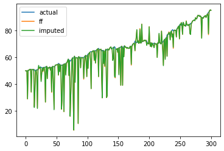

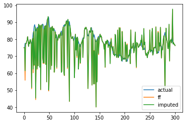

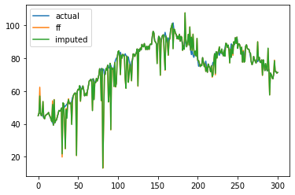

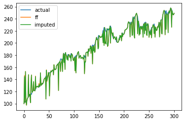

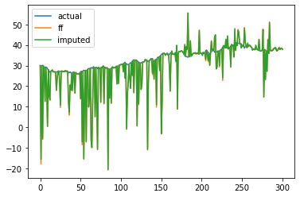

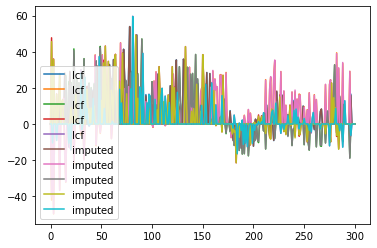

```
error lcf=394.17336702435045and error imputed391.90483054050287
```

```python
imputed_data_mock = pickle.load(open('data_mock_imputed.p', 'rb'))
imputed_data_mock = imputed_data_mock.drop(['theta', 'sigma'], axis=1)
complete_data_mock = pickle.load(open('data_mock_complete.p', 'rb'))
for col in file_list:
    plt.plot(complete_data_mock[col], label='actual')
    plt.plot(data_mock_ff[col], label = 'ff')
    plt.plot(imputed_data_mock[col],label = 'imputed')
    plt.legend()
    plt.show()

error_lcf = complete_data_mock.subtract(data_mock_ff)
error_imputed = complete_data_mock.subtract(imputed_data_mock)

plt.plot(error_lcf, label='lcf')
plt.plot(error_imputed, label='imputed')
plt.legend()
plt.show()

error_lcf = error_lcf**2
error_lcf = (error_lcf.values.sum())**.5
error_imputed = error_imputed**2
error_imputed = (error_imputed.values.sum())**.5
print('error lcf='+str(error_lcf)+'and error imputed'+ str(error_imputed))
```

## 5. Implementation on Real data

```python
data = pickle.load(open('real_data_original.p', 'rb'))
data = data.reset_index()
data = data.drop(['Time'],axis=1)
# remove the initial data where everything is nan
start_id = 0
for i, r in data.iterrows():
    if not(r.isna().values.all(axis=0)):
        start_id = i
        break

data = data.iloc[start_id:]
data = data.reset_index()
data = data.drop(['index'],axis=1)

time_series_ff = time_series_ff.drop(['level_0','index'],axis=1)
```

```python
data_new = pd.DataFrame(columns=['apple', 'google', 'microsoft','facebook', 'amazon', 'theta', 'sigma'])


total_index_arr = np.array([0, 1, 2, 3, 4])
look_back = 10

initial_mean = time_series_ff.mean(axis=0).to_numpy()
initial_lambda_inv = 20 * np.diag(np.ones(5))

time_series_ff = time_series_ff.fillna(value= {'apple':initial_mean[0], 'google':initial_mean[1],
                                      'microsoft':initial_mean[2], 'facebook': initial_mean[3],
                                               'amazon':initial_mean[4]})

deg_free = 10
iter_num = 100

# for each t find the best estimate
for index, row in data.iterrows():
    look_back_list = [max(index - i, 0) for i in range(1, look_back + 1)]
    arr = np.array(look_back_list)
    look_back_list = np.unique(arr).tolist()
    look_back_period = len(np.unique(arr))

    y = row.to_numpy()

    non_zero_index = np.where(y)[0]
    zero_index = np.setdiff1d(total_index_arr, non_zero_index)

    # initial y estimate estimate

    y = time_series_ff.iloc[index].to_numpy()

    relevant_df = pd.DataFrame(columns=['apple', 'google', 'microsoft','facebook', 'amazon'])
    relevant_df = relevant_df.append(time_series_ff.iloc[look_back_list])

    # initial sigma  estimate estimate

    if index < 2:
        sigma = 20 * np.diag(np.ones(5))
    else:
        sigma = relevant_df.cov().to_numpy()

    theta = np.zeros(len(data_mock_ff.iloc[1]))

    theta_sim = 0
    sigma_sim = 0
    y_sim = 0

    for i in range(iter_num):
        # starting gibbs sampler
        y_sim += y
        new_row = {'apple': y[0], 'google': y[1], 'microsoft': y[2], 'facebook': y[3], 'amazon': y[4]}

        relevant_df = relevant_df.append(new_row, ignore_index=True)

        mean_y_look_back = relevant_df.mean().to_numpy()

        relevant_df = relevant_df[:-1]

        # sample theta
        a = np.linalg.pinv(initial_lambda_inv + look_back_period * np.linalg.pinv(sigma))
        b = np.matmul(initial_lambda_inv, initial_mean) + look_back_period * np.matmul(np.linalg.pinv(sigma),
                                                                                       mean_y_look_back)
        mean_theta_look_back = np.matmul(a, b)
        var_theta_look_back = np.linalg.pinv(initial_lambda_inv + look_back_period * np.linalg.pinv(sigma))
        theta = stats.multivariate_normal.rvs(mean_theta_look_back, var_theta_look_back,size=100)
        theta = theta.mean(axis=0)

        theta_sim += theta

        # using theta, sample sigma
        s_theta = np.matmul(np.transpose(y - theta), (y - theta))
        x = np.linalg.pinv(s_theta + np.linalg.pinv(initial_lambda_inv))
        try:
            np.linalg.cholesky(x)
        except np.linalg.LinAlgError:
            eigen_val, eigen_vector = np.linalg.eig(x)
            eigen_val[eigen_val <= 0] = 1
            x = np.diag(eigen_val)


        sigma = stats.invwishart.rvs(deg_free + look_back_period, x, size=100)
        sigma = sigma.mean(axis=0)

        sigma_sim += sigma

        if zero_index.size:
            # sample y_missing using theta, sigma
            sigma_b = sigma[zero_index, :]
            sigma_a = sigma[non_zero_index, :]
            sigma_b_a = sigma_b[:, non_zero_index]
            sigma_a_b = sigma_a[:, zero_index]
            sigma_a_a = sigma_a[:, non_zero_index]
            sigma_b_b = sigma_b[:, zero_index]
            sigma_mul = np.matmul(sigma_b_a, np.linalg.pinv(sigma_a_a))
            theta_p = theta[zero_index] + np.matmul(sigma_mul, np.subtract(y[non_zero_index], theta[non_zero_index]))
            sigma_p = sigma_b_b - np.matmul(sigma_mul, sigma_a_b)
            y_mis = stats.multivariate_normal.rvs(theta_p, sigma_p,size=100)
            y_mis = y_mis.mean(axis=0)
            y[zero_index] = y_mis

    theta = theta_sim/iter_num
    sigma = sigma_sim/ iter_num
    y = y_sim/iter_num

    row = {'apple': y[0], 'google': y[1], 'microsoft': y[2], 'facebook': y[3], 'amazon': y[4],
           'theta': theta, 'sigma': sigma}
    data_new = data_new.append(row, ignore_index=True)

pickle.dump(data_new, open('data_imputed.p', 'wb'))
```

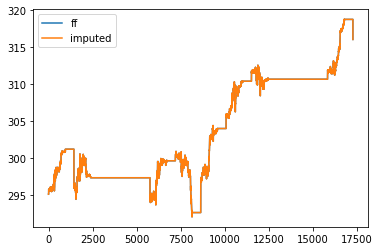

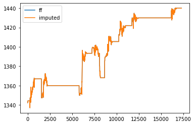

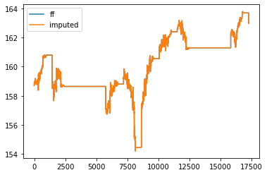

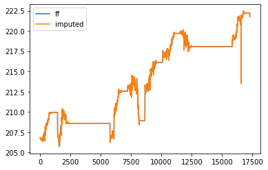

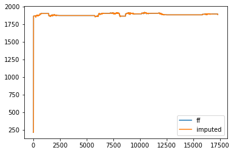

```python
imputed_data = pickle.load(open('data_imputed.p', 'rb'))

imputed_data = imputed_data.drop(['theta', 'sigma'], axis=1)

for col in file_list:
    plt.plot(time_series_ff[col], label = 'ff')
    plt.plot(imputed_data[col],label = 'imputed')
    plt.legend()
    plt.show()
```